## Programmation avec R

### B.Thieurmel - benoit.thieurmel@quadratic-labs.com

[figure not shown]

[figure not shown]

# Bonne pratique de codage

Librement inspiré du [Style Guide, by Hadley Wickham](http://adv-r.had.co.nz/Style.html)

- C’est important d’adopter des bonnes pratiques de codages :
  - permettre une lecture et une compréhension simple et rapide du code
  - tant pour le(s) développeur(s), que pour les utilisateurs, et favoriser le travail collaboratif
- Il n’y a pas un style parfait, le principal est d’en adopter un et de s’y tenir

```r
# dur à lire
aze=data.frame(cole=rnorm(1000),refdzf=LETTERS[1:2]);ff=lapply(split(aze$cole,aze$refdzf),
                                                               function(x){mean(x)});ff
```

```r
# c'est mieux quand même... ?
data <- data.frame(value = rnorm(1000), group = LETTERS[1:2])
mean.group <- lapply(
  split(data$value, data$group),
  function(x){
    mean(x)
  })
mean.group
```

# Fichiers

Les noms doivent être **explicites** et se terminer par `.R`. Si les scripts sont ordonnés, les pré-fixer par un numéro.

```
# Good            # Bad         0-download.R
modelisation.R    toto.r        1-parse.R
```

# Variables et fonctions

- Noms **courts** et **explicites**, de préférence en minuscule, en évitant d’utiliser des noms de fonctions connues…
- Utilisation d’un underscore (`_`) pour séparer les noms. Eviter le point (`.`), il peut amener de mauvaises intéractions avec d’autres langages (java, javascript, …)
- Variable == noms, fonctions == verbes, autant que possible….
- **Pas d’accents !**

```r
# Good                    # Bad
day_one                   first_day_of_the_month
day_1                     DayOne
                          mean <- function(x) sum(x)
```

# Espacer son code

- Mettre des espaces **autour** de tous les opérateurs (`=`, `+`, `-`, `<-`, etc.), **surtout** à l’intérieur de l’appel d’une fonction.
- Mettre un espace **après** une virgule, **pas avant**
- Essayer de mettre un espace avant l’ouverture d’une parenthèse, **sauf dans l’appel d’une fonction**

```r
# Good
average <- mean(feet / 12 + inches, na.rm = TRUE)

# Bad
average<-mean(feet/12+inches,na.rm=TRUE)
```

- Exception pour `:`, `::` and `:::`

```r
# Good                     # Bad
x <- 1:10                  x <- 1 : 10
base::get                  base :: get

if (debug) do(x)           if(debug)do(x)
plot(x, y)                 plot (x, y)
```

# Namespace et appel d’une fonction

- `::` accès aux fonctions exportées d’un package
- `:::` accès aux fonctions *cachées* d’un package

**Bonne pratique**

- essayer de toujours préfixer l’appel à une fonction par `::`
  - obligatoire pour une soumission d’un package sur le CRAN
  - meilleure lisibilité des appels / dépendances
  - évite des conflits potentiels : deux fonctions du même nom dans deux packages différents…
- éviter l’utilisation des fonctions *cachées* `:::`
  - interdit pour une soumission d’un package sur le CRAN

```r
require(FactoMineR)

# Good
FactoMineR::PCA(X, scale.unit = TRUE)
```

# Accolades et indentation

- L’ouverture d’une accolade doit **toujours** être suivi d’un passage à la ligne.
- La fermeture d’un accolade doit être suivi d’un passage à la ligne, sauf dans le cas d’un **else**
- Le code à l’interieur des acccolades doit être indenté

```r
# Good                            # Bad
if (y == 0) {                     if (y == 0) {
  log(x)                            log(x)
} else {                          }
  y ^ x                           else{ y ^ x}
}
```

- Indenter son code, de préférence en utilisant deux espaces. **Raccourci RStudio : Ctrl+A, Ctrl+I**

# Assignement

- Utiliser `<-`, et **banir** `=`, lors de l’assignement

```r
# Good
x <- 5
# Bad
x = 5
```

# Commentaires

- Commenter son code, toujours dans un soucis de lecture et de collaboration. **Raccourci RStudio : Ctrl+Shift+C**
- un commentaire comportant au-moins `----` créé une section pouvant être réduite

```r
# Load data ---------------------------

# Plot data ---------------------------
```

# Opérateurs logiques

- **==**, **!=**, **>**, **<**, **>=**, **<=**

```r
x <- 1

x == 1  # TRUE
x != 1  # FALSE
x < 1   # FALSE

vx <- c(1, 2)
vx != 1 # FALSE TRUE
```

- **any** : retourne vrai si au-moins un élément répond à la condition

```r
x <- c(1:10)

any(x == 10) # TRUE
any(x > 10)  # FALSE
```

- **all** : retourne vrai si tous les éléments répondent à la condition

```r
x <- c(1:10)

all(x <= 10) # TRUE
all(x > 10)  # FALSE
```

- **%in%** : vérifie l’appartenance de chaque élément d’un vecteur à un autre ensemble

```r
x <- "rennes"
x %in% c("rennes", "brest") # TRUE

x <- c("rennes", "paris")
x %in% c("rennes", "brest") # TRUE FALSE
```

- **is.vector**, **is.data.frame**, **is.list**, …

```r
x <- c(1:10)

is.vector(x) # TRUE
```

- **!** : retourne la négation

```r
x <- 1
y <- 10

(x == 1 & y == 10)   # TRUE
!(x == 1 & y == 10)  # FALSE
```

- **&** : opérateur logique ‘AND’. Vrai si les deux conditions sont vraies, faux sinon

```r
(x == 1 & y == 10)   # TRUE
(x == 1 & y == 9)  # FALSE
```

- **|** : opérateur logique ‘OR’. Vrai si au-moins une des deux conditions est vraie, faux sinon

```r
(x == 1 | y == 10)   # TRUE
(x == 1 | y == 9)    # TRUE
(x == 2 | y == 9)    # FALSE
```

- **xor** : opérateur logique ‘OR’ exclusif. Vrai si une et une seule condition est vraie, faux sinon

```r
xor(TRUE, FALSE) # TRUE
xor(TRUE, TRUE)  # FALSE
```

# Structures condionnelles

### if / else/ else if

```r
if(condition1){
  print("la condition1 est vrai")
}else if(condition2){
  print("la condition1 est fausse, mais la condition2 est vrai")
}else{
  print("les conditions sont fausses... :-(")
}
```

- la condition doit retourner une (**et une seule**) valeur logique (TRUE/FALSE)

### ifelse, une variante

```r
ifelse(vecteur.condition, vecteur.vrai, vecteur.faux)
```

- Pour chaque élément *i*, regarde *condition[i]*, et retourne *vrai[i]* ou *faux[i]*

```r
x <- 1:2
ifelse(x%%2 == 0, 0, x)     #> [1] 1 0
```

### switch

- Suivant les cas, une autre façon de faire un **if / else if**

```r
res <-  switch(valeur,
         cas1 = resultat1,
         cas2 = resultat2,
         cas3 = resultat3,
         sinon (optionnel))
```

```r
fonction <- "mean"
x <- rnorm(100)
res <-  switch(fonction,
         "mean" = mean(x),
         "median" = median(x),
         "sum" = sum(x))
res
```

```
## [1] 0.04660961
```

# Les boucles

- Rarement efficaces…
- Donc à utiliser avec précautions dans **R**
- Utiliser de préférence les propriétés offertes par la **vectorisation**, et la **“Apply Family”**

### For

On parcourt un ensemble d’éléments

```r
for(variable in elements){
  ...
}
```

```r
for(lettre in LETTERS[1:2]){
  print(lettre)
}
```

```
## [1] "A"
## [1] "B"
```

### While

- Tant que la condition est vrai, on continue
  - Si elle est fausse au départ, rien ne s’éxécute
  - Si elle est toujours vraie, ou s’il n’y a pas de sortie **explicite**, elle continue à tourner…!

```r
while(condition){
  ...
}
```

```r
x <- 1
while(x < 4){
  print(x)
  x <- x+1
}
```

```
## [1] 1
## [1] 2
## [1] 3
```

### Repeat

- Tant qu’on ne sort pas, on continue
  - L’éxécution a donc lieu au-moins une fois
  - Utilisation de **break** pour sortir

```r
repeat{
  ...
  if(condition) break
}
```

```r
x <- 1
repeat{
  x <- x+1
  if(x == 3){
    print("x vaut 3, on s'arrête.")
    break
  }
}
```

```
## [1] "x vaut 3, on s'arrête."
```

### Break et next

- **break** : Sortie immédiate d’une boucle **for**, **while** ou **repeat**
- **next** : Itération suivante d’une boucle **for**, **while** ou **repeat**

```r
for(i in 1:3){
  if(i%%2 != 0) {
    next
  }
  print(i)
}
```

```
## [1] 2
```

# Les fonctions

On définit une nouvelle fonction avec la syntaxe suivante :

```
fun <- function(arguments) expression
```

- **fun** le nom de la fonction
- **arguments** la liste des arguments, séparés par des virgules. *formals(fun)*
- **expression** le corps de la fonction. une seul expression, ou plusieurs entre des accolades. *body(fun)*

```r
test <- function(x) x^2
test              # function(x) x^2

formals(test)     # $x
body(test)        # x^2
environment(test) # <environment: R_GlobalEnv>
```

- Une fonction appartient à un environnement. Le plus souvent un package, ou alors l’environnement global **GlobalEnv**. *environment(fun)*

# Les arguments

- **Valeur par défaut**
  - via une affetaction, avec ‘=’, dans la définition de la fonction
  - optionnel lors de l’appel

```r
test <- function(x, y = 2){
  x + y
}
test(x = 2)           # 4
test(x = 2, y = 10)   # 12
```

- **Quelques fonctions utiles de contrôle :**
  - *missing(arg)* : retourne TRUE si l’argument est manquant lors de l’appel
  - *match.arg()* : en cas d’input tronqué…
  - *typeof(arg)*, *class(arg)*, *is.vector()*, *is.data.frame()*, ….

```r
match.arg("mea", c("mean", "sum", "median"))  # "mean"
class(10)                                     # "numeric"
```

# Dépendances entre arguments

On peut définir un argument en fonction d’autres arguments

```r
# avec une expression simple
test <- function(x, y = x + 10){
  x + y
}
test(5)  # 20

# un peu plus compliqué
test <- function(x,
                 fun = if(class(x) %in% c("numeric", "integer")){
                   "sum"
                 }else{
                    "length"
                 }){

  do.call(fun, list(x = x))

}

test(1:10)            #55
test(LETTERS[1:10])   #10
```

# Evaluation des arguments

**Point Important** : les arguments ne sont évalués que lorsqu’ils sont appelés, sinon ils n’existent pas dans la fonction…. Pour forcer l’évaluation, on peut utiliser la fonction *force()*. Démonstration :

```r
f <- function(x) {
  10
}
f(stop("This is an error!"))

# la fonction retourne 10 alors que l'argument est un stop...
# 10

# utilisation de force
f <- function(x) {
  force(x)
  10
}
f(stop("This is an error!"))

# Error: This is an error!
```

# Comprendre les ‘…’ (1/2)

- Signifie que la fonction accepte d’autres arguments que ceux définis explicitement
- Sert généralement à passer ces arguments à une autre fonction
- Se récupère facilement avec : *list(…)*

```r
viewdot <- function(arg, ...){
  list(...)
}
viewdot(arg = 1, x = 2, name = "name")

#$x
#[1] 2
#
#$name
#[1] "name"

rnormPlot <- function(n, mean = 0, sd = 1, ...){
  plot(rnorm(n = n, mean = mean, sd = sd), ...)
}
rnormPlot(n = 100, main = "Comprendre les ...", col = "red", pch = 10)
```

# Comprendre les ‘…’ (2/2)

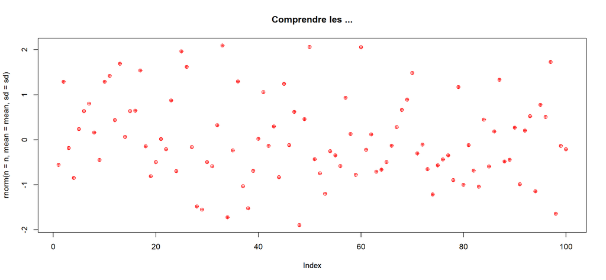

# Retourner un résultat

Une fonction retourne par défaut le résultat de la dernière expression

```r
test <- function(x, y = 2){
  x + y
}
test(2)
```

```
## [1] 4
```

```r
somme <- test(x = 2, y = 2)
somme
```

```
## [1] 4
```

- Renvoi d’un résultat avant la fin de la fonction : fonction *return()*
- Utilisation de *return()* pour la dernière expression ? **Inutile**.
- Retour de plusieurs résultats : liste nommée.
- Aucun résultat ? Possible avec par example la fonction *invisible()*

# Fonction return()

```r
test <- function(x, y = 2){
  if(y == 0){
    return(x)
  }
  x + y
}
test(2)
```

```
## [1] 4
```

- Plusieurs résultats

```r
test <- function(x, y = 2){
  list(x = x, y = y)
}
test(2)
```

```
## $x
## [1] 2
##
## $y
## [1] 2
```

# Fonction invisible()

*“This function can be useful when it is desired to have functions return values which can be assigned, but which do not print when they are not assigned”*

```r
test <- function(x, y = 2){
  x + y
  invisible()
}
test(2)  # no print on console
res <- test(2)
res     # and NULL result
```

```r
test <- function(x, y = 2){
  invisible(x + y)
}
test(2)  # no print on console
res <- test(2)
res      # but a result !
```

```
## [1] 4
```

# Variables locales et globales

- Une variable définie dans une fonction est **locale** :
  - elle ne sera pas présente ensuite dans l’espace de travail
  - elle n’écrasera pas une variable du même nom existante

```r
x <- 100
test <- function(x, y){
  x <- x + y
  x
}

# la fonction retourne bien 10
test(5, 5)
```

```
## [1] 10
```

```r
# et x vaut bien toujours 100
x
```

```
## [1] 100
```

# Affectation globale

- Via l’opérateur d’affectation `<<-`, on peut affecter au modifier une variable **globale**
- Autant que possible **non-recommandé**…!

```r
x <- 100
test <- function(x, y){
  x <<- x + y
  y <<- y
  x
}

# la fonction retourne ...  5 ?
test(5, 5)
```

```
## [1] 5
```

```r
# et x vaut maintenant 10, et y 5
x ; y
```

```
## [1] 10
```

```
## [1] 5
```

# Appel d’une variable non-définie ?

```r
test <- function(x){
  x + z
}

# Erreur, z n'existe pas
test(5)
```

```
#> Error in test(5) : object 'z' not found
```

```r
# Si, à tout hasard, une variable 'z' existe dans un autre environnement
# au moment de l'appel, la fonction l'utilise...
z <- 5
test(5)
```

```
#> 10
```

- **R** va chercher une variable d’une même nom dans les environnements *parents*. Pratique également à éviter.

**Il faut passer tous les arguments en paramètres, et retourner l’ensemble des résultats souhaités en sortie**

# Fonctions anonymes

Comme son nom l’indique, une fonction qui n’a pas de nom…

- fonction courte, utilisée dans une autre fonction
- qui n’a pas pour but d’être ré-utilisée par la suite

```r
f <- function(x){
  x + 1
}

res1 <- sapply(1:10, f)

res2 <- sapply(1:10, function(x) x + 1)

res1
```

```
##  [1]  2  3  4  5  6  7  8  9 10 11
```

```r
res2
```

```
##  [1]  2  3  4  5  6  7  8  9 10 11
```

# Communication

Quand on développe, il est important d’anticiper les problèmes potentiels du code :

- mauvais type d’argument
- fichier non-existant
- données manquantes, valeurs infinies, …

Et communiquer avec l’utilisateur. Trois niveaux sont disponibles :

- fonction *stop()* : erreur “fatale”, l’éxécution se termine. A utiliser quand la suite du code ne peut pas être éxécutée
- fonction *warning()* : problème “potentielle”, l’éxécution continue, mais il y aura peut-être un soucis…
- fonction *message()* : message “informatif”, l’éxécution continue.

# Communication : exemple

```r
test <- function(x){
  # pour une erreur plus compréhensible
  if(missing(x)){
    stop("x is missing. Please enter a valid argument")
  }
  if(!class(x) %in% c("numeric", "integer")){
    x <- as.numeric(as.character(x))
    warning("x is coerced to numeric")
  }
  message("compute x*2")
  x*2
}

try(test())
```

```
## Error in test() : x is missing. Please enter a valid argument
```

```
#> Error: x is missing. Please enter a valid argument
```

```r
test("5")
```

```
## compute x*2
```

```
## [1] 10
```

# Et la documentation dans tout ça ?

La documentation est très importante :

- pour que l’utilisateur sache comment utiliser la fonction
- pour vous et d’autres développeurs, lors d’améliorations

**Adopter la convention *doxygen***

- simple d’utilisation
- utiliser dans de nombreux langages de programmation
- via le package [roxygen2](https://cran.r-project.org/web/packages/roxygen2/vignettes/roxygen2.html), vous simplifiera ensuite la vie si vous créez des packages !

**Utilisation dans R**

Le plus simple : placer le curseur au-niveau de la fonction et faire *Code -> Insert roxygen Skeleton* ou bien utiliser le raccourci clavier associé

- en commençant la ligne par `#'`

http://r-pkgs.had.co.nz/man.html

# Les balises indispensables

- @param : pour les arguments
- @return : pour le résultat
- @examples : pour les exemples
- @import : packages dépendants utilisés
- @importFrom : packages dépendants utilisés (mais importation uniquement de quelques fonctions)

**Penser à préfixer le nom des fonctions utilisées par le `package::fonction`, et cela même pour les packages de base** :

```r
# Bad                         # Good
res_pca <- PCA(decathlon)     res_pca <- FactoMineR::PCA(decathlon)
```

# exemple de documentation

```r
#' le titre de ma fonction
#'
#' Une description succinte de ma fonction
#' sur plusieurs lignes si on veut
#'
#' @param nom : Character. Nom de la personne
#' @param prenom : Character. Prénom de la personne
#'
#' @return : Character. Identification de la personne
#'
#' @importFrom base paste0
#'
#' @examples
#' # les examples sont éxécutables dans RStudio avec Ctrl+Entrée
#' identify("Thieurmel", "Benoit")
identify <- function(nom, prenom){
  base::paste0("Nom :", nom, ", prénom : ", prenom)
}
```

# La “Apply family”

**R** donc pas au top pour interpréter et éxécuter efficacement des boucles **for**

- Une solution **radicale** : NE PAS LES UTILISER !
- Penser à la vectorisation
- Utiliser la **“Apply family”**
  - **apply** : appliquer une fonction sur un data.frame, une matrice, ou un tableau multi-dimentionnel
  - **lapply** : appliquer une fonction sur une liste, ou un vecteur, et retourne une liste
  - **sapply** : identique à **lapply**, mais essaye de structurer un peu mieux les résultats si cela est possible
  - **vapply** : identique à **sapply**, en permettant de définir (un peu) le format des résultats
  - **mapply** : prend en entrée plusieurs vecteurs/listes, et applique la fonction sur les premiers éléments de chaque entrées, puis sur les seconds, ….
  - **rapply** : éxécution récursive de **apply**, avec contrôle préalable des éléments
  - **tapply** : calculs par sous-population

### Apply

```r
apply(X, MARGIN, FUN, ...)
```

- **X** : une matrice ou un tableau
- **MARGIN** : un vecteur d’entiers contenant la ou les dimensions sur lesquelles on souhaite appliquer la fonction (1 : lignes, 2 : colonnes)
- **FUN** : la fonction à appliquer
- **…** : ensemble d’arguments supplémentaires, à passer à la fonction

```r
x <- cbind(x1 = 3, x2 = c(NA, 4:1, 2:6))
apply(x, 2, mean)                  # moyenne par colonnes
```

```
## x1 x2
##  3 NA
```

```r
apply(x, 2, mean, na.rm = TRUE)    # en passant un argument
```

```
##       x1       x2
## 3.000000 3.333333
```

### lapply, sapply, vapply

```r
lapply(X, FUN, ...)

sapply(X, FUN, ..., simplify = TRUE, USE.NAMES = TRUE)

vapply(X, FUN, FUN.VALUE, ..., USE.NAMES = TRUE)
```

- **X** : un vecteur ou une liste
- **FUN** : la fonction à appliquer à tous les éléments de *X*
- **…** : ensemble d’arguments supplémentaires, à passer à la fonction
- **simplify** : booléan ou caractère, pour simplifier les résultats
- **USE.NAMES** : booléan. Si *X* est nommé, les utiliser dans les résultats ?
- **FUN.VALUE** : un “template” pour les résultats

Essayons de comprendre ces petites différences…

**1. Calcul de la moyenne, soit une valeur par élément**

- les données de départ :

```r
x <- list(a = 1:3, b = rnorm(5))
```

[output not shown]

- lapply retourne donc une liste

```r
lapply(x, FUN = mean)
```

```
## $a
## [1] 2
##
## $b
## [1] 0.6521952
```

- sapply simplifie les résultats dans un vecteur

```r
sapply(x, FUN = mean)
```

```
##         a         b
## 2.0000000 0.6521952
```

- vapply attend une précision sur le résulat

```r
# on s'attend à récupérer une valeur numérique
vapply(x, FUN = mean, FUN.VALUE = 0)
```

```
##         a         b
## 2.0000000 0.6521952
```

```r
# et si on s'attend à récupérer une valeur logique ?
vapply(x, FUN = mean, FUN.VALUE = TRUE)

# Error in vapply(x, FUN = mean, FUN.VALUE = TRUE) :
#   values must be type 'logical',
#  but FUN(X[[1]]) result is type 'double'
```

**2. Calcul des quantiles, soit 5 valeurs par éléments**

- lapply retourne donc une liste

```r
lapply(x, FUN = quantile)
```

```
## $a
##   0%  25%  50%  75% 100%
##  1.0  1.5  2.0  2.5  3.0
##
## $b
##        0%       25%       50%       75%      100%
## 0.1644995 0.2279881 0.2473968 0.8223570 1.7987345
```

- sapply simplifie les résultats dans une matrix

```r
sapply(x, FUN = quantile)
```

```
##        a         b
## 0%   1.0 0.1644995
## 25%  1.5 0.2279881
## 50%  2.0 0.2473968
## 75%  2.5 0.8223570
## 100% 3.0 1.7987345
```

- Formattage avec vapply

```r
vapply(x, FUN = quantile, FUN.VALUE = c(Min. = 0, "1st Qu." = 0,
  Median = 0, "3rd Qu." = 0, Max. = 0))
```

```
##           a         b
## Min.    1.0 0.1644995
## 1st Qu. 1.5 0.2279881
## Median  2.0 0.2473968
## 3rd Qu. 2.5 0.8223570
## Max.    3.0 1.7987345
```

**3. Et si on retourne un nombre variable d’éléments ?**

```r
la <- lapply(x, FUN = function(elm) elm)
sa <- sapply(x, FUN = function(elm) elm)
# vapply pas pertinent

identical(la, sa)
```

```
## [1] TRUE
```

### mapply

```r
mapply(FUN, ..., MoreArgs = NULL, SIMPLIFY = TRUE,
       USE.NAMES = TRUE)
```

- **FUN** : la fonction à appliquer
- **…** : ensemble d’arguments, vecteurs ou listes
- **MoreArgs** : liste d’arguments supplémentaires pour la fonction
- **SIMPLIFY** : booléan ou charactère, pour simplifier les résultats
- **USE.NAMES** : booléan. Si noms il y a dans X, les utiliser dans les résultats ?

```r
mapply(rep, 1:2, 2:1)
```

```
## [[1]]
## [1] 1 1
##
## [[2]]
## [1] 2
```

```r
# en nommant les arguments
mapply(rep, times = 1:2, x = 2:1)
```

```
## [[1]]
## [1] 2
##
## [[2]]
## [1] 1 1
```

```r
# en passant des arguments supplémentaires
mapply(rep, times = 1:2, MoreArgs = list(x = 100))
```

```
## [[1]]
## [1] 100
##
## [[2]]
## [1] 100 100
```

```r
# Avec simplification des résultats
mapply(function(n, moy) mean(rnorm(n, moy)), n = c(100, 1000), moy = c(10, 0))
```

```
## [1] 9.92046694 0.04369885
```

### tapply

```r
tapply(X, INDEX, FUN = NULL, ...,
       default = NA, simplify = TRUE)
```

- **X** : la colonne / le vecteur utilisé(e) dans le calcul
- **INDEX** : liste du / des facteurs définissant les populations
- **FUN** : la fonction à appliquer
- **…** : ensemble d’arguments supplémentaires, à passer à la fonction
- **simplify** : booléan ou charactère, pour simplifier les résultats

```r
head(warpbreaks, n =4)
```

```
##   breaks wool tension
## 1     26    A       L
## 2     30    A       L
## 3     54    A       L
## 4     25    A       L
```

```r
tapply(X = warpbreaks$breaks,
       INDEX = warpbreaks[,-1], FUN = sum)
```

```
##     tension
## wool   L   M   H
##    A 401 216 221
##    B 254 259 169
```

```r
tapply(X = warpbreaks$breaks,
       INDEX = list(warpbreaks$wool), FUN = sum)
```

```
##   A   B
## 838 682
```

# Le calcul parallèle

### Concept

- Calcul séquentiel
  - un problème est divisé en une série d’instructions
  - les instructions sont éxécutées les une après les autres
  - sur une seule unité de calcul
  - seulement une instruction s’exécute à la fois

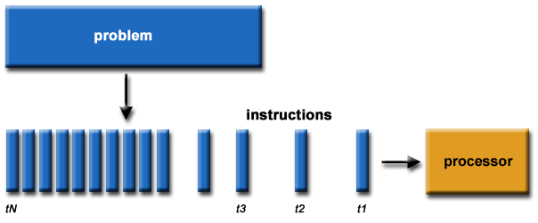

- Calcul parallèle
  - un problème put être divisé en plusieurs séries d’instructions indépendantes pouvant s’exécuter en même temps
  - les instructions de chaque série s’éxécute simultanément sur différentes unités de calcul
  - les résultats obtenus sur chaque unité de calcul sont renvoyés dans le processus parent
  - cela nécessite un méchanisme de contrôle et de synchronisation

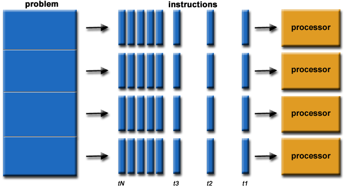

*‘l’ensemble des techniques logicielles et matérielles permettant l’exécution simultanée de séquences d’instructions indépendantes sur des processeurs et/ou coeurs différents’*

Le problème algorithmique est donc :

- pouvoir diviser tout ou une partie en sous-calculs indépendants
- pouvoir éxécuter plusieurs instructions à un moment donné
- résoudre le problème en moins de temps qu’avec un calcul séquentiel

Les ressources matérielles à disposition :

- un unique ordinateur, avec plusieurs processeurs / coeurs
- un cluster d’ordinateurs inter-connectés

[figure not shown]

### Quand paralléliser ?

- quand chaque calcul commence à prendre un peu de temps…
- calculer plusieurs tâches rapides en parallèle prend en général plus de temps qu’avec un calcul séquentiel…
- faire attention au partage des données, et regarder l’évolution de la performance en fonction du nombre de coeurs
- le mieux : tester et comparer !

[figure not shown]

### les outils dans R

- A la base, **R** est mono-coeur
- De [nombreux packages](https://cran.r-project.org/web/views/HighPerformanceComputing.html) permettant le calcul parallèle existent. Voir https://cran.r-project.org/web/views/HighPerformanceComputing.html

Nous nous focaliserons sur deux packages :

- le package **parallel**
  - inclu dans R depuis R.2.14.0
  - basé sur deux “anciens” packages : **snow** et **multicore**
  - propose une interface très proche de la **‘Apply family’**
- le package **foreach**

```r
require(parallel)
vignette("parallel")

require(foreach)
vignette("foreach")
```